# Tugas Analisis Regresi Pertemuan 7

Qonita Husnia Rahmah

2024-03-05

## Library

```r
library(tidyverse)
library(ggridges)
library(GGally)
library(dplyr)
library(lmtest)
library(stats)
```

## Data

```r
library(readxl)
DataRegresi <- read_xlsx("C:\\Users\\ASUS\\Documents\\Nita\\SEMESTER 4\\Analisis Regresi\\Kuliah\\Data Tugas Pertemuan 7.xlsx")
DataRegresi
```

```
## # A tibble: 15 × 3
##       No     X     Y
##    <dbl> <dbl> <dbl>
##  1     1     2    54
##  2     2     5    50
##  3     3     7    45
##  4     4    10    37
##  5     5    14    35
##  6     6    19    25
##  7     7    26    20
##  8     8    31    16
##  9     9    34    18
## 10    10    38    13
## 11    11    45     8
## 12    12    52    11
## 13    13    53     8
## 14    14    60     4
## 15    15    65     6
```

```r
Y<-DataRegresi$Y
X<-DataRegresi$X

data<-data.frame(cbind(X, Y))
head(data)
```

```
##    X  Y
## 1  2 54
## 2  5 50
## 3  7 45
## 4 10 37
## 5 14 35
## 6 19 25
```

### Scatter Plot Antara X dan Y

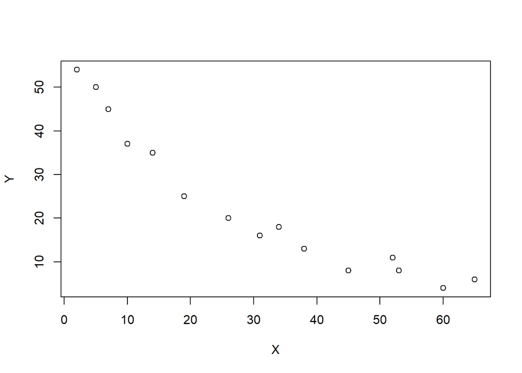

```r
plot(X,Y)
```

Dari scatter plot antara X dan Y, dapat dilihat bahwa X dan Y memiliki hubungan yang tidak linear cenderung membentuk parabola.

### Pemodel Regresi Linear

```r
model <- lm(formula = Y ~ X, data = data)
summary(model)
```

```
##
## Call:
## lm(formula = Y ~ X, data = data)
##
## Residuals:
##     Min      1Q  Median      3Q     Max
## -7.1628 -4.7313 -0.9253  3.7386  9.0446
##
## Coefficients:
##             Estimate Std. Error t value Pr(>|t|)
## (Intercept) 46.46041    2.76218   16.82 3.33e-10 ***
## X           -0.75251    0.07502  -10.03 1.74e-07 ***
## ---
## Signif. codes:  0 '***' 0.001 '**' 0.01 '*' 0.05 '.' 0.1 ' ' 1
##
## Residual standard error: 5.891 on 13 degrees of freedom
## Multiple R-squared:  0.8856, Adjusted R-squared:  0.8768
## F-statistic: 100.6 on 1 and 13 DF,  p-value: 1.736e-07
```

```r
model
```

```
##
## Call:
## lm(formula = Y ~ X, data = data)
##
## Coefficients:
## (Intercept)            X
##     46.4604      -0.7525
```

# Eksplorasi Kondisi Gauss-Markov, Peneriksaan dengan Grafik

## Plot Sisaan vs Y duga

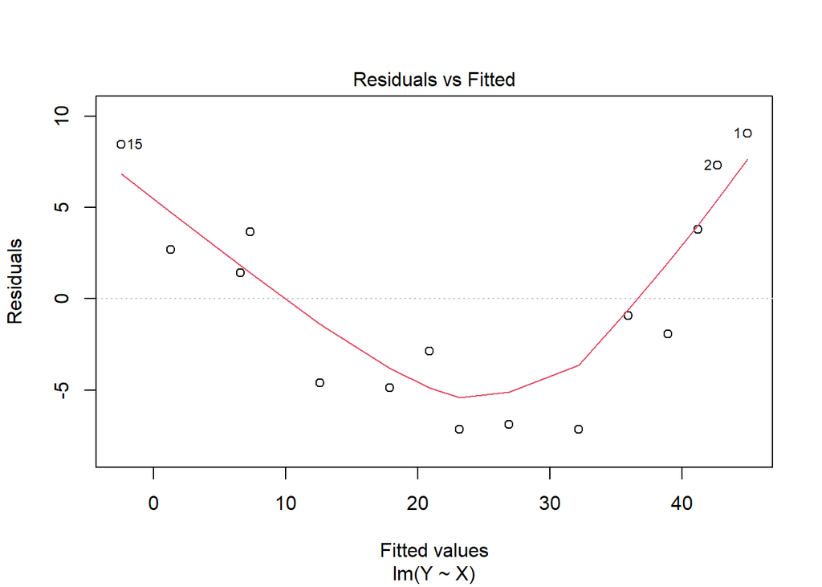

```r
plot(model,1)
```

## Plot Sisaan vs Urutan

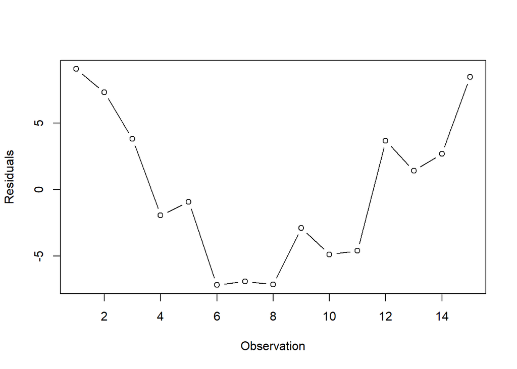

```r
 plot(x = 1:dim(data)[1],
 y = model$residuals,
 type = 'b',
 ylab = "Residuals",
 xlab = "Observation")
```

Sebaran membentuk pola kurva, artinya Sisaan tidak saling bebas

## Normalitas Sisaan dengan QQ-Plot

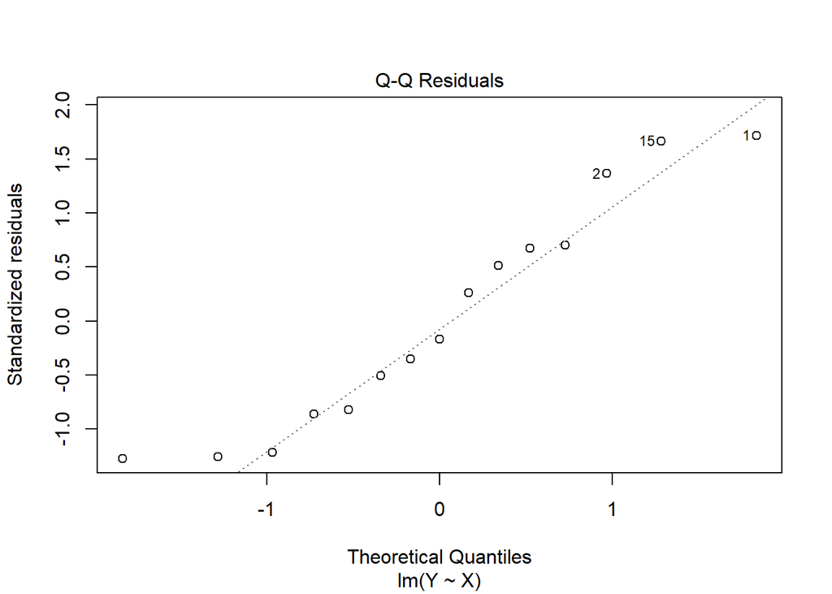

```r
plot(model,2)
```

# Pengujian Asumsi

## Uji Asumsi Gauss-Markov

### 1. Nilai Harapan Sisaan sama dengan nol

$$H_0 : \text{Nilai harapan sama dengan 0}\\H_1 : \text{Nilai harapan
tidak sama dengan 0}$$

```r
t.test(model$residuals,mu = 0,conf.level = 0.95)
```

```
##
##  One Sample t-test
##
## data:  model$residuals
## t = -4.9493e-16, df = 14, p-value = 1
## alternative hypothesis: true mean is not equal to 0
## 95 percent confidence interval:
##  -3.143811  3.143811
## sample estimates:
##     mean of x
## -7.254614e-16
```

Dalam pengujian asumsi Gauss-Markov yang pertama, didapat bahwa p-value > 0.05, maka tak tolak $H_0$, ataun nilai harapan sisaan sama dengan nol

### 2. Ragam Sisaan Homogen (Homogenitas)

$$H_0 : \text{Ragam sisaan homogen}\\H_1 : \text{Ragam sisaan tidak
homogen}$$

```r
kehomogenan = lm(formula = abs(model$residuals) ~ X,
data = data)
summary(kehomogenan)
```

```
##
## Call:
## lm(formula = abs(model$residuals) ~ X, data = data)
##
## Residuals:
##     Min      1Q  Median      3Q     Max
## -4.2525 -1.7525  0.0235  2.0168  4.2681
##
## Coefficients:
##             Estimate Std. Error t value Pr(>|t|)
## (Intercept)  5.45041    1.27241   4.284  0.00089 ***
## X           -0.01948    0.03456  -0.564  0.58266
## ---
## Signif. codes:  0 '***' 0.001 '**' 0.01 '*' 0.05 '.' 0.1 ' ' 1
##
## Residual standard error: 2.714 on 13 degrees of freedom
## Multiple R-squared:  0.02385,    Adjusted R-squared:  -0.05124
## F-statistic: 0.3176 on 1 and 13 DF,  p-value: 0.5827
```

```r
bptest(model)
```

```
##
##  studentized Breusch-Pagan test
##
## data:  model
## BP = 0.52819, df = 1, p-value = 0.4674
```

Didapat bahwa p-value > 0.05, maka taktolak $H_0$, atau ragam sisaan homogen untk setiap nilai x.

### 3. Sisaan Saling Bebas/Tidak Ada Autokorelasi

$$H_0 : \text{Sisaan saling bebas}\\H_1 : \text{Sisaan tidak saling bebas}$$

```r
library (randtests)
runs.test(model$residuals)
```

```
##
##  Runs Test
##
## data:  model$residuals
## statistic = -2.7817, runs = 3, n1 = 7, n2 = 7, n = 14, p-value =
## 0.005407
## alternative hypothesis: nonrandomness
```

```r
dwtest(model)
```

```
##
##  Durbin-Watson test
##
## data:  model
## DW = 0.48462, p-value = 1.333e-05
## alternative hypothesis: true autocorrelation is greater than 0
```

Didapat bahwa p-value < 0.05, maka tolak $H_0$, atau sisaan tidak saling bebas(terdapat autokorelasi)

## Uji Normalitas Sisaan

$$H_0 : \text{Sisaan menyebar normal}\\H_1 : \text{Sisaan tidak menyebar
normal}$$

```r
shapiro.test(model$residuals)
```

```
##
##  Shapiro-Wilk normality test
##
## data:  model$residuals
## W = 0.92457, p-value = 0.226
```

Dari Uji Shapiro-Wilk, didapat hasil bahwa p-value > alpha, maka tak tolak $H_0$, atau sisaan menyebar normal dengan alpha 0.05.

## Kesimpulan

Dari ketiga asumsi Gauss-Markov yang ada, didapat hasil bahwa terdapat asumsi yang tidak terpenuhi yaitu pelanggaran asumsi tidak ada autokorelasi dengan melihat Durbin Watson Test yang telah dilakukan.

# Penanganan Kondisi Tak Standar

## Transformasi Data

```r
new_x <- sqrt(data$X)
new_y <- sqrt(data$Y)
transformasi <- data.frame(new_x, new_y)
transformasi
```

```
##       new_x    new_y
## 1  1.414214 7.348469
## 2  2.236068 7.071068
## 3  2.645751 6.708204
## 4  3.162278 6.082763
## 5  3.741657 5.916080
## 6  4.358899 5.000000
## 7  5.099020 4.472136
## 8  5.567764 4.000000
## 9  5.830952 4.242641
## 10 6.164414 3.605551
## 11 6.708204 2.828427
## 12 7.211103 3.316625
## 13 7.280110 2.828427
## 14 7.745967 2.000000
## 15 8.062258 2.449490
```

### Plot Baru

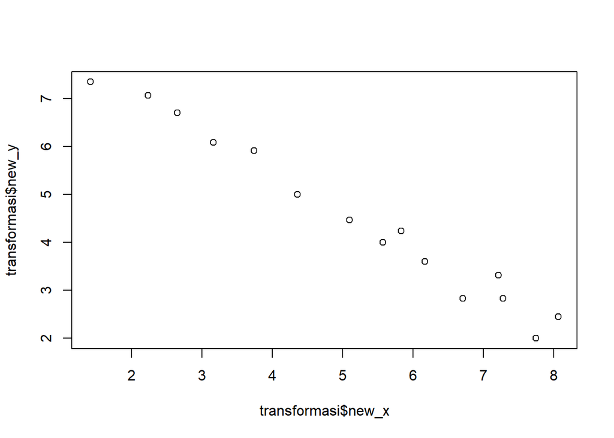

```r
plot(transformasi$new_x, transformasi$new_y)
```

### Model Linear Baru

```r
ModelBaru <- lm(transformasi$new_y ~ transformasi$new_x, data=transformasi)
summary (ModelBaru)
```

```
##
## Call:
## lm(formula = transformasi$new_y ~ transformasi$new_x, data = transformasi)
##
## Residuals:
##      Min       1Q   Median       3Q      Max
## -0.42765 -0.17534 -0.05753  0.21223  0.46960
##
## Coefficients:
##                    Estimate Std. Error t value Pr(>|t|)
## (Intercept)         8.71245    0.19101   45.61 9.83e-16 ***
## transformasi$new_x -0.81339    0.03445  -23.61 4.64e-12 ***
## ---
## Signif. codes:  0 '***' 0.001 '**' 0.01 '*' 0.05 '.' 0.1 ' ' 1
##
## Residual standard error: 0.2743 on 13 degrees of freedom
## Multiple R-squared:  0.9772, Adjusted R-squared:  0.9755
## F-statistic: 557.3 on 1 and 13 DF,  p-value: 4.643e-12
```

```r
ModelBaru
```

```
##
## Call:
## lm(formula = transformasi$new_y ~ transformasi$new_x, data = transformasi)
##
## Coefficients:
##        (Intercept)  transformasi$new_x
##             8.7125             -0.8134
```

# Eksplorasi Kondisi Gauss-Markov, Peneriksaan dengan Grafik

## Plot Sisaan vs Y duga

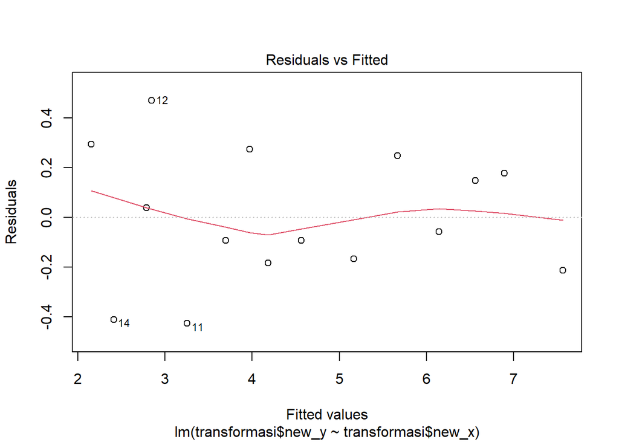

```r
plot(ModelBaru,1)
```

## Plot Sisaan vs Urutan

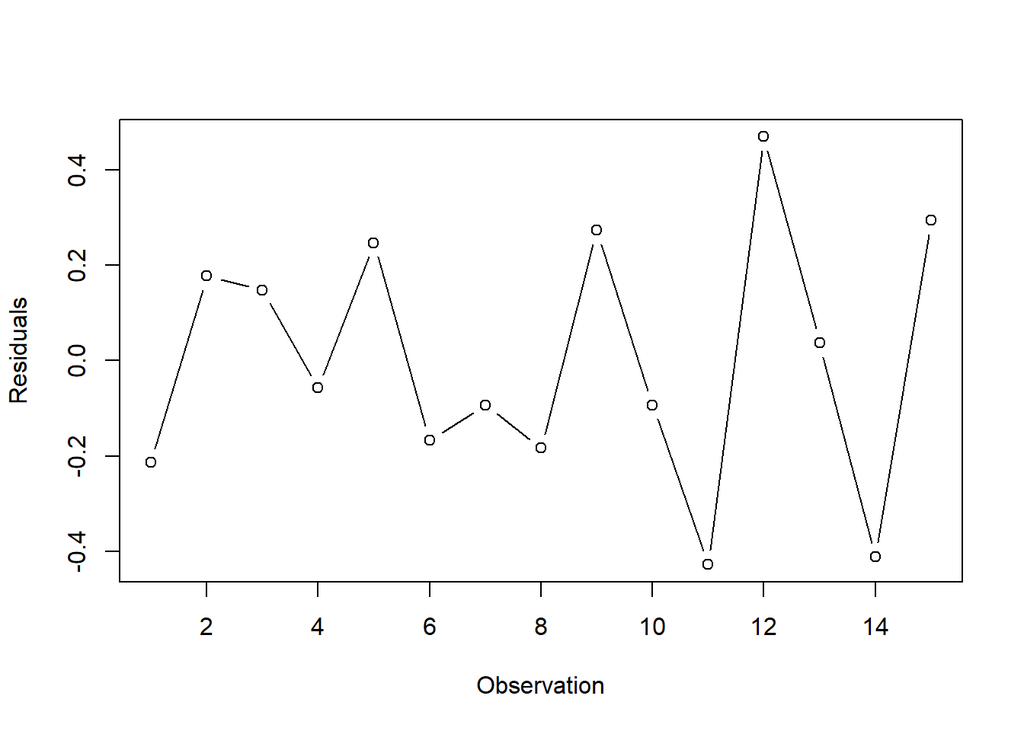

```r
 plot(x = 1:dim(transformasi)[1],
 y = ModelBaru$residuals,
 type = 'b',
 ylab = "Residuals",
 xlab = "Observation")
```